# Problems and Windowing

# Problem specifications: running ConScape at scale

ConScape is now designed for running at very large scales with high resolution, such as 50m pixels for a whole country.

However, this will not work if a the exploratory approach used in the other examples is scaled up naively.

For best performance at scale all details of a `solve` for all required `Measure`s should be included in a single `ConScape.Problem`.

Then, to limit the size of each solve to below a 1000 * 1000 Raster is prudent, and as the solve becomes expensive, saving an intermediate file reduces the chance of catastropic errors losing large amounts of computation.

To do this we wrap a problem in a `BatchProblem` (one window saved to disk per batch) or a `WindowedProblem` wrapped in a `BatchProblem`, (many windows mosaiced then saved to disk each batch).

This example will document this workflow.

For production scripts for running this on a slurm cluster, see the ConScapeJobs repository in the ConScape github organisation.

[output not shown]

# Data import

```
"/home/runner/work/ConScape.jl/ConScape.jl/src/../data"
```

Unlike our other examples, we load these files with `lazy=true` assuming they will be very large. With a batch problem, there is no need to load the whole raster dataset for each windowed job. ConScape will later read just the range that it needs from the lazy raster.

```
┌ 117×87 RasterStack ┐
├────────────────────┴─────────────────────────────────────────────────── dims ┐
  ↓ X Projected{Float64} 110650.0:1000.0:226650.0 ForwardOrdered Regular Intervals{Start},
  → Y Projected{Float64} 6.98175e6:-1000.0:6.89575e6 ReverseOrdered Regular Intervals{Start}
├────────────────────────────────────────────────────────────────────── layers ┤
  :steplikelihood eltype: Float64 dims: X, Y size: 117×87
  :sourcequality  eltype: Float64 dims: X, Y size: 117×87
├────────────────────────────────────────────────────────────────────── raster ┤
  missingval: NaN
  extent: Extent(X = (110650.0, 227650.0), Y = (6.89575e6, 6.98275e6))
  crs:
└──────────────────────────────────────────────────────────────────────────────┘
```

## Padding

Using BatchProblem or WindowedProblem we lose the buffer edge around the Raster no targets are calculated in this regions.

It may be inconvenient to write a new file that pads this reason, and in Julia it is unnesessary. We can just lazily pad the underlying DiskArray.

# Problem definition

For large batches, always write all measures in one problem, and call `solve` once. This means computations will be shared accross all measures.

First define measures as a `NamedTuple`. These names will be the layer names of the output `RasterStack`.

```
(func_hab = FunctionalHabitat(), betq = Betweenness{QualityWeighted}(QualityWeighted()), betm = MovementFlow(QualityAndProximityWeighted()))
```

Then define a movement mode:

```
RandomisedShortestPath{ExpectedCost, ExpMinus, Float64, Float64}(ExpectedCost(), ExpMinus(), 1.0, 1.0, false)
```

And define the complete Problem:

```
ConScapeProblem

measures:             (func_hab = FunctionalHabitat(), betq = Betweenness{QualityWeighted}(QualityWeighted()), betm = MovementFlow(QualityAndProximityWeighted()))
movement:             RandomisedShortestPath{ExpectedCost, ExpMinus, Float64, Float64}(ExpectedCost(), ExpMinus(), 1.0, 1.0, false)
costfunction:         MinusLog()
likelihoodfunction:   nothing
solver:               ConScape.ColumnSolver()
grain:                nothing
stepweight:           TargetWeight()
neighbors:            N8
mmap_path:        nothing
```

## Solving

We can now solve the problema as one unit, all measure are calculated simultaneously and share many computations.

```
┌ 117×87 RasterStack ┐
├────────────────────┴─────────────────────────────────────────────────── dims ┐
  ↓ X Projected{Float64} 110650.0:1000.0:226650.0 ForwardOrdered Regular Intervals{Start},
  → Y Projected{Float64} 6.98175e6:-1000.0:6.89575e6 ReverseOrdered Regular Intervals{Start}
├────────────────────────────────────────────────────────────────────── layers ┤
  :func_hab eltype: Float64 dims: X, Y size: 117×87
  :betq     eltype: Float64 dims: X, Y size: 117×87
  :betm     eltype: Float64 dims: X, Y size: 117×87
├────────────────────────────────────────────────────────────────────── raster ┤
  missingval: NaN
  extent: Extent(X = (110650.0, 227650.0), Y = (6.89575e6, 6.98275e6))
  crs:
└──────────────────────────────────────────────────────────────────────────────┘
```

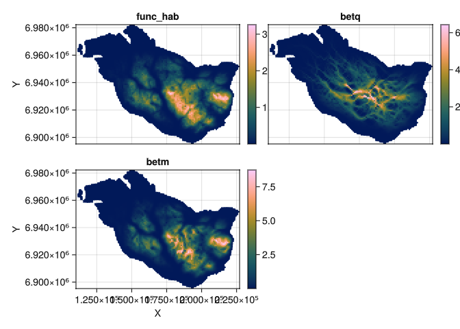

# WindowedProblem

To split the raster into multiple overlapping windows, we can use a `WindowedProblem`, that simply wraps a regular `Problem` and adds windowing parameters.

These are `buffer` and `centersize`, and `threaded`. The `buffer` is the amount of source pixels around the target pixels. The number will depend on the decay parameters used for proximity calculations. The buffer size should capture all pixels where values may be significantly larger than zero.

As the number of targets decreases the relative cost of initialising sources increases, and performance will decline. As the number increases, the memory use increases. Try a few numbers separately to find a sweet-spot for you particular problem and infrastructure. `20` may be a good starting point. We use `10` here because of the small rasters used for demonstration purposes.

If you run ConScape.jl on a node with multiple cores, you usually want `threaded=true` here, to utilise all of them. Also make sure Julia is run with threads by checking:

```
1
```

And calling julia with `julia --threads=8` etc. `--threads=auto` may lead to two threads per physical core, which may not improve efficiency of ConScape.jl as CPUs will likely be well utilised by a single thread.

Now, define the windowed problem:

```
WindowedProblem{ConScapeProblem{RandomisedShortestPath{ExpectedCost, ExpMinus, Float64, Float64}, @NamedTuple{func_hab::FunctionalHabitat, betq::Betweenness{QualityWeighted}, betm::MovementFlow}, ConScape.ColumnSolver, Nothing, MinusLog, Nothing, NTuple{8, Tuple{Int64, Int64, Float64, Int64}}, Targe…
```

Run it to show that it works

```
Mosaicing 3 layers of 39 regions with sum...   2%|▉                                                 |  ETA: 0:01:25
Mosaicing 3 layers of 39 regions with sum... 100%|██████████████████████████████████████████████████| Time: 0:00:01
 37.749398 seconds (28.59 M allocations: 1.628 GiB, 61.81% gc time, 29.80% compilation time: <1% of which was recompilation)
```

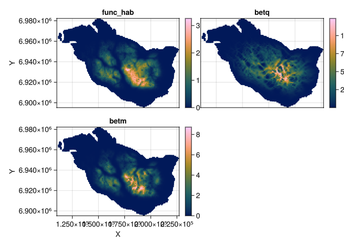

# Batch problems

Large scale computations usually occurr accross separate “nodes” of a cluster. These are not separate CPU cores that can be threaded accross windows, but physically separate machines connected on a network.

Usually, tasks are broeken into multiple separate batches and combined afterwards, such as with slurm array batches.

To facilitate this workflow ConScape.jl defines `BatchProblem`.

It has the key properties:

- batches can be assessed and thinned to only those that need to run.
- batch numbers are always *sequential* so they are easy to specify in slurm scripts.
- each batch is written to a separate folder of raster files.
- progress can be reassessed after errors.
- `solve` is run using an ID: `solve(batch_problem, rast, id)` so only that subsection is run.
- `solve` is usually run with an assessment: `solve(batch_problem, assessment, rast, id)` required batch ids are not recalculated (which will often often take longer than running the job itself!)

```
BatchProblem{WindowedProblem{ConScapeProblem{RandomisedShortestPath{ExpectedCost, ExpMinus, Float64, Float64}, @NamedTuple{func_hab::FunctionalHabitat, betq::Betweenness{QualityWeighted}, betm::MovementFlow}, ConScape.ColumnSolver, Nothing, MinusLog, Nothing, NTuple{8, Tuple{Int64, Int64, Float64, I…
```

# Batch assessment

Usually in very large rasters there will be many windows that contain only zeros or missing values, and do not need to be run.

For Norway, a long diagonal country, over 80% of the possible batches do not run. Prefiltering these jobs reduces the number of launches and lets us know when we are really finished by knowing a-priori which output paths must contain data.

The `assess` function carries out this assessment, checking all windows for data and recording which need to run.

```
Assessing 40 jobs
Assessing batch: 1, (1:50, 1:50)
Assessing batch: 2, (11:60, 1:50)
Assessing batch: 3, (21:70, 1:50)
Assessing batch: 4, (31:80, 1:50)
Assessing batch: 5, (41:90, 1:50)
Assessing batch: 6, (51:100, 1:50)
Assessing batch: 7, (61:110, 1:50)
Assessing batch: 8, (71:117, 1:50)
Assessing batch: 9, (1:50, 11:60)
Assessing batch: 10, (11:60, 11:60)
Assessing batch: 11, (21:70, 11:60)
Assessing batch: 12, (31:80, 11:60)
Assessing batch: 13, (41:90, 11:60)
Assessing batch: 14, (51:100, 11:60)
Assessing batch: 15, (61:110, 11:60)
Assessing batch: 16, (71:117, 11:60)
Assessing batch: 17, (1:50, 21:70)
Assessing batch: 18, (11:60, 21:70)
Assessing batch: 19, (21:70, 21:70)
Assessing batch: 20, (31:80, 21:70)
Assessing batch: 21, (41:90, 21:70)
Assessing batch: 22, (51:100, 21:70)
Assessing batch: 23, (61:110, 21:70)
Assessing batch: 24, (71:117, 21:70)
Assessing batch: 25, (1:50, 31:80)
Assessing batch: 26, (11:60, 31:80)
Assessing batch: 27, (21:70, 31:80)
Assessing batch: 28, (31:80, 31:80)
Assessing batch: 29, (41:90, 31:80)
Assessing batch: 30, (51:100, 31:80)
Assessing batch: 31, (61:110, 31:80)
Assessing batch: 32, (71:117, 31:80)
Assessing batch: 33, (1:50, 41:87)
  No targets found
Assessing batch: 34, (11:60, 41:87)
Assessing batch: 35, (21:70, 41:87)
Assessing batch: 36, (31:80, 41:87)
Assessing batch: 37, (41:90, 41:87)
Assessing batch: 38, (51:100, 41:87)
Assessing batch: 39, (61:110, 41:87)
Assessing batch: 40, (71:117, 41:87)
```

```
ConScape.NestedAssessment
Shape: (8, 5)
Number of jobs: 39
Memory estimate: 6.0 MB
Job mask:
 true  true  true  true    ⋅
 true  true  true  true   true
 true  true  true  true   true
 true  true  true  true   true
 true  true  true  true   true
 true  true  true  true   true
 true  true  true  true   true
 true  true  true  true   true
```

Usually, the result should be written to disk to be used accross separate nodes.

JSON is an easy, human readble format for saving assements.

```
"batches/assessment.json"
```

Later you can read this directly into a `NestedAssessment` object`:

```
ConScape.NestedAssessment
Shape: (8, 5)
Number of jobs: 39
Memory estimate: 6.0 MB
Job mask:
 true  true  true  true    ⋅
 true  true  true  true   true
 true  true  true  true   true
 true  true  true  true   true
 true  true  true  true   true
 true  true  true  true   true
 true  true  true  true   true
 true  true  true  true   true
```

# Solve

Usually we solve batch problems individualy, on a single cluster node.

Here we solve the first one:

```
(func_hab = "batches/batch_1_1/func_hab.tif", betq = "batches/batch_1_1/betq.tif", betm = "batches/batch_1_1/betm.tif")
```

Note the result is the names of the files for each measure, not the output data.

We can also solve them all at once, mostly as a demonstration convenience:

```
39-element Vector{@NamedTuple{func_hab::String, betq::String, betm::String}}:
 (func_hab = "batches/batch_1_1/func_hab.tif", betq = "batches/batch_1_1/betq.tif", betm = "batches/batch_1_1/betm.tif")
 (func_hab = "batches/batch_11_1/func_hab.tif", betq = "batches/batch_11_1/betq.tif", betm = "batches/batch_11_1/betm.tif")
 (func_hab = "batches/batch_21_1/func_hab.tif", betq = "batches/batch_21_1/betq.tif", betm = "batches/batch_21_1/betm.tif")
 (func_hab = "batches/batch_31_1/func_hab.tif", betq = "batches/batch_31_1/betq.tif", betm = "batches/batch_31_1/betm.tif")
 (func_hab = "batches/batch_41_1/func_hab.tif", betq = "batches/batch_41_1/betq.tif", betm = "batches/batch_41_1/betm.tif")
 (func_hab = "batches/batch_51_1/func_hab.tif", betq = "batches/batch_51_1/betq.tif", betm = "batches/batch_51_1/betm.tif")
 (func_hab = "batches/batch_61_1/func_hab.tif", betq = "batches/batch_61_1/betq.tif", betm = "batches/batch_61_1/betm.tif")
 (func_hab = "batches/batch_71_1/func_hab.tif", betq = "batches/batch_71_1/betq.tif", betm = "batches/batch_71_1/betm.tif")
 (func_hab = "batches/batch_1_11/func_hab.tif", betq = "batches/batch_1_11/betq.tif", betm = "batches/batch_1_11/betm.tif")
 (func_hab = "batches/batch_11_11/func_hab.tif", betq = "batches/batch_11_11/betq.tif", betm = "batches/batch_11_11/betm.tif")
 ⋮
 (func_hab = "batches/batch_61_31/func_hab.tif", betq = "batches/batch_61_31/betq.tif", betm = "batches/batch_61_31/betm.tif")
 (func_hab = "batches/batch_71_31/func_hab.tif", betq = "batches/batch_71_31/betq.tif", betm = "batches/batch_71_31/betm.tif")
 (func_hab = "batches/batch_11_41/func_hab.tif", betq = "batches/batch_11_41/betq.tif", betm = "batches/batch_11_41/betm.tif")
 (func_hab = "batches/batch_21_41/func_hab.tif", betq = "batches/batch_21_41/betq.tif", betm = "batches/batch_21_41/betm.tif")
 (func_hab = "batches/batch_31_41/func_hab.tif", betq = "batches/batch_31_41/betq.tif", betm = "batches/batch_31_41/betm.tif")
 (func_hab = "batches/batch_41_41/func_hab.tif", betq = "batches/batch_41_41/betq.tif", betm = "batches/batch_41_41/betm.tif")
 (func_hab = "batches/batch_51_41/func_hab.tif", betq = "batches/batch_51_41/betq.tif", betm = "batches/batch_51_41/betm.tif")
 (func_hab = "batches/batch_61_41/func_hab.tif", betq = "batches/batch_61_41/betq.tif", betm = "batches/batch_61_41/betm.tif")
 (func_hab = "batches/batch_71_41/func_hab.tif", betq = "batches/batch_71_41/betq.tif", betm = "batches/batch_71_41/betm.tif")
```

# Reassessment

When all jobs for a `BatchProblem` appear to be finished, we need to check that they actually are! Various errors may have occurred when running on a cluster.

The `reassess` function cheaply reassesses the situation from a BatchProblem definition and a previous output of `assess` or `reassess`, like a `NestedAssessment`. It simply checks that the output folders exist (TODO: it should actually check that each file exists?).

```
ConScape.NestedAssessment
Shape: (8, 5)
Number of jobs: 0
Memory estimate: 6.0 MB
Job mask:
   ⋅      ⋅      ⋅      ⋅      ⋅
   ⋅      ⋅      ⋅      ⋅      ⋅
   ⋅      ⋅      ⋅      ⋅      ⋅
   ⋅      ⋅      ⋅      ⋅      ⋅
   ⋅      ⋅      ⋅      ⋅      ⋅
   ⋅      ⋅      ⋅      ⋅      ⋅
   ⋅      ⋅      ⋅      ⋅      ⋅
   ⋅      ⋅      ⋅      ⋅      ⋅
```

It is reccomended to always save a copy of the original (expensive) output of `assess` if overwriting the working assessment file with the output of `reassess` - as information is lost in the reassessment.

# Mosaicing outputs

After running batch problems `Rasters.mosaic` can be used to recombine them into a single contiguous raster. In ConScape.jl spatial outputs with overlapping sources but non-overlapping targets can always be summed.

We can get all the paths that would produce output using `ConScape.batch_paths`:

```
39-element Vector{String}:
 "batches/batch_1_1"
 "batches/batch_11_1"
 "batches/batch_21_1"
 "batches/batch_31_1"
 "batches/batch_41_1"
 "batches/batch_51_1"
 "batches/batch_61_1"
 "batches/batch_71_1"
 "batches/batch_1_11"
 "batches/batch_11_11"
 ⋮
 "batches/batch_61_31"
 "batches/batch_71_31"
 "batches/batch_11_41"
 "batches/batch_21_41"
 "batches/batch_31_41"
 "batches/batch_41_41"
 "batches/batch_51_41"
 "batches/batch_61_41"
 "batches/batch_71_41"
```

[output not shown]

[output cut: 23 more lines]

Using the `to` command means we get a raster for identical spatial region of the input. Otherwise the padding may be included to return a larger raster, or if windows allow a whole edge were empty they the raster may be smaller than the original.

In the simplest case, this command is all you need:

```
Mosaicing 3 layers of 39 regions with sum...   2%|▉                                                 |  ETA: 0:02:45
Mosaicing 3 layers of 39 regions with sum... 100%|██████████████████████████████████████████████████| Time: 0:00:02
```

```
┌ 117×87 RasterStack ┐
├────────────────────┴─────────────────────────────────────────────────── dims ┐
  ↓ X Projected{Float64} 110650.0:1000.0:226650.0 ForwardOrdered Regular Intervals{Start},
  → Y Projected{Float64} 6.98175e6:-1000.0:6.89575e6 ReverseOrdered Regular Intervals{Start}
├────────────────────────────────────────────────────────────────────── layers ┤
  :betm     eltype: Float64 dims: X, Y size: 117×87
  :betq     eltype: Float64 dims: X, Y size: 117×87
  :func_hab eltype: Float64 dims: X, Y size: 117×87
├────────────────────────────────────────────────────────────────────── raster ┤
  missingval: NaN
  extent: Extent(X = (110650.0, 227650.0), Y = (6.89575e6, 6.98275e6))
  crs:
└──────────────────────────────────────────────────────────────────────────────┘
```

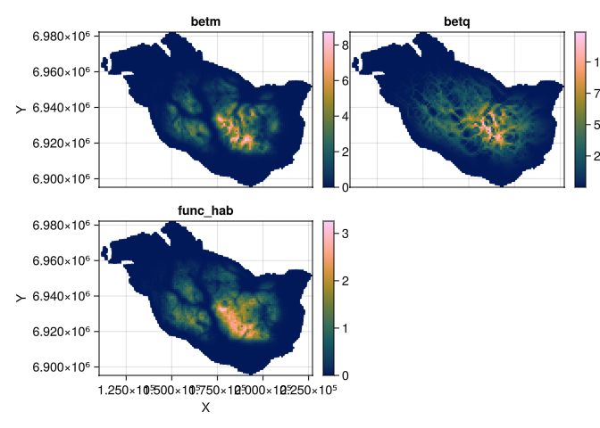

At very large scales mosaic to memory may cause problems. If the output is very large you may want to write directly to disk.

```
┌ Warning: Cannot write complete stacks to ".tif", writing layers as individual files
└ @ Rasters ~/.julia/packages/Rasters/G6rYV/src/write.jl:129

Mosaicing 3 layers of 39 regions with sum...   2%|▉                                                 |  ETA: 0:02:18
Mosaicing 3 layers of 39 regions with sum... 100%|██████████████████████████████████████████████████| Time: 0:00:02
```

```
┌ 117×87 RasterStack ┐
├────────────────────┴─────────────────────────────────────────────────── dims ┐
  ↓ X Projected{Float64} 110650.0:1000.0:226650.0 ForwardOrdered Regular Intervals{Start},
  → Y Projected{Float64} 6.98175e6:-1000.0:6.89575e6 ReverseOrdered Regular Intervals{Start}
├────────────────────────────────────────────────────────────────────── layers ┤
  :betm     eltype: Float64 dims: X, Y size: 117×87
  :betq     eltype: Float64 dims: X, Y size: 117×87
  :func_hab eltype: Float64 dims: X, Y size: 117×87
├────────────────────────────────────────────────────────────────────── raster ┤
  missingval: NaN
  extent: Extent(X = (110650.0, 227650.0), Y = (6.89575e6, 6.98275e6))
  crs:
  filename: (betm = "dest_file_betm.tif", betq = "dest_file_betq.tif", func_hab = "dest_file_func_hab.tif")
└──────────────────────────────────────────────────────────────────────────────┘
```

Also see production examples in ConScapeJobs.jl.

Notably this application: - wraps all batch problem and data loads in a function so they are identical for all purposes - facilitates working with multiple datasets at once (e.g. multiple species / parameters) with named batch commands, e.g.: `sbatch run.sh reindeer_alpine` - adds a compilation directive so that code is precompiled for exactly your dataset, saving the minute or so that each node would take to compile the task